# Stat_analysis_zebra_SR

Justine Boutry

2023-01-22

# Determination of sex in embryos injected with an oncogenic plasmid and in their offspring

```r
F0 <- read_delim("F0.csv",
    delim = ";", escape_double = FALSE, trim_ws = TRUE)

F0$SR <- F0$Nb_Female/F0$Nb_tot

F0$Aquarium <- as.factor(F0$Aquarium)
F0$GFP <- as.factor(F0$GFP)

summary(F0)
```

```
##      Exp               Aquarium   GFP       Nb_male        Nb_Female
##  Length:17          1      : 1   Neg:9   Min.   : 4.00   Min.   : 8.00
##  Class :character   2      : 1   Pos:8   1st Qu.:10.00   1st Qu.: 9.00
##  Mode  :character   3      : 1           Median :11.00   Median :11.00
##                     4      : 1           Mean   :11.24   Mean   :10.88
##                     5      : 1           3rd Qu.:13.00   3rd Qu.:12.00
##                     6      : 1           Max.   :17.00   Max.   :16.00
##                     (Other):11
##      Nb_tot            SR
##  Min.   :15.00   Min.   :0.3846
##  1st Qu.:19.00   1st Qu.:0.4211
##  Median :23.00   Median :0.4783
##  Mean   :22.18   Mean   :0.4993
##  3rd Qu.:25.00   3rd Qu.:0.5600
##  Max.   :33.00   Max.   :0.7333
##
```

# Analysis of the sexe ratios in the F0

## Graphical representation

```r
# Confident interval calculations

prop.test(sum(F0$Nb_Female[F0$GFP=="Pos"]), sum(F0$Nb_tot[F0$GFP=="Pos"]))
```

```
##
##  1-sample proportions test with continuity correction
##
## data:  sum(F0$Nb_Female[F0$GFP == "Pos"]) out of sum(F0$Nb_tot[F0$GFP == "Pos"]), null probability 0.5
## X-squared = 0.10738, df = 1, p-value = 0.7431
## alternative hypothesis: true p is not equal to 0.5
## 95 percent confidence interval:
##  0.4338454 0.5988334
## sample estimates:
##         p
## 0.5167785
```

```r
prop.test(sum(F0$Nb_Female[F0$GFP=="Neg"]), sum(F0$Nb_tot[F0$GFP=="Neg"]))
```

```
##
##  1-sample proportions test with continuity correction
##
## data:  sum(F0$Nb_Female[F0$GFP == "Neg"]) out of sum(F0$Nb_tot[F0$GFP == "Neg"]), null probability 0.5
## X-squared = 0.5307, df = 1, p-value = 0.4663
## alternative hypothesis: true p is not equal to 0.5
## 95 percent confidence interval:
##  0.4077056 0.5405642
## sample estimates:
##         p
## 0.4736842
```

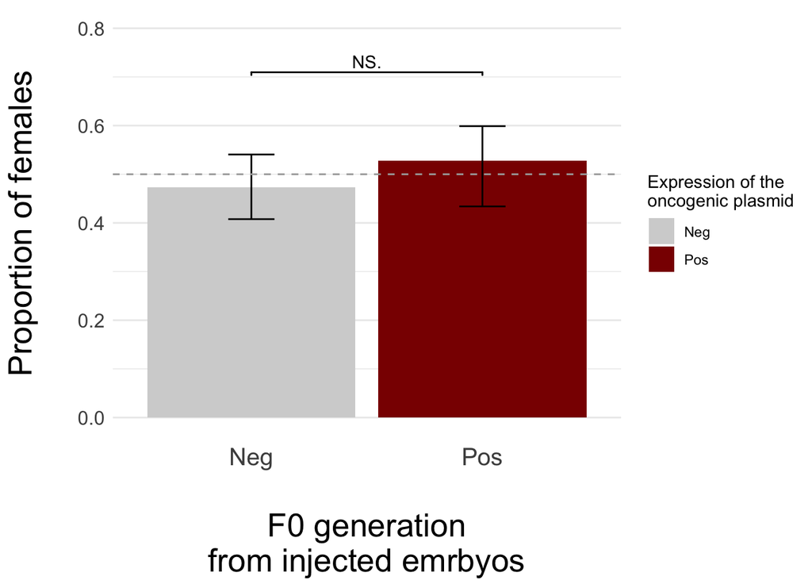

```r
df <- data.frame(GFP=c("Neg", "Pos"),
                moy=c(
                  mean(F0[F0$GFP=="Neg",]$Nb_Female/F0[F0$GFP=="Neg",]$Nb_tot),
                  mean(F0[F0$GFP=="Pos",]$Nb_Female/F0[F0$GFP=="Pos",]$Nb_tot)),
                born.inf=c(0.4077056,0.4338454),
                born.sup=c(0.5405642,0.5988334))

(a <- ggplot(data = df, aes(y=moy, x=GFP, fill=GFP))+
  geom_bar(stat="identity")+
  geom_errorbar(aes(ymin=born.inf, ymax=born.sup), width=.2,
                 position=position_dodge(.9))+
  #geom_point(aes(color=GFP), size = 3, alpha = .8)+
  geom_hline(yintercept=0.5, lty=2, color="darkgrey")+
  ylim(0,0.8)+
  labs(color="Expression of the \noncogenic plasmid", fill="Expression of the \noncogenic plasmid")+
  ylab("Proportion of females\n")+
  xlab("\nF0 generation\nfrom injected emrbyos")+
  scale_fill_manual(values = c("lightgrey", "darkred"))+
  scale_color_manual(values = c("lightgrey", "darkred"))+
  theme_minimal()+
  theme(
    panel.grid.major.x = element_blank(),
        axis.title.x=element_text(vjust=0,
                                  size=20),  # X axis title
        axis.title.y=element_text(size=20, angle = 90),  # Y axis title
        axis.text.x=element_text(size=15,
                                 vjust=.5),  # X axis text
        axis.text.y=element_text(size=12))+
   ggsignif::geom_signif(comparisons = list(c("Neg", "Pos")), map_signif_level = TRUE, y_position = 0.7))
```

```r
ggsave("SR_F0.jpg", a, device = "jpg")
```

### Random effect selection

```r
mod_SR_RN <- glmmTMB(data=F0, cbind(Nb_Female, Nb_male)~GFP*Nb_tot+ (1|Exp/Aquarium), family = "binomial", REML = F)
mod_SR_R1 <- glmmTMB(data=F0, cbind(Nb_Female, Nb_male)~GFP*Nb_tot+ (1|Aquarium), family = "binomial", REML = F)
mod_SR_R0 <- glmmTMB(data=F0, cbind(Nb_Female, Nb_male)~GFP*Nb_tot, family = "binomial", REML = F)
AICc(mod_SR_RN, mod_SR_R1,  mod_SR_R0)
```

```
##           df     AICc
## mod_SR_RN  6 86.08966
## mod_SR_R1  5 81.14421
## mod_SR_R0  4 77.02300
```

```r
Weights(AICc(mod_SR_RN, mod_SR_R1,  mod_SR_R0))
```

```
##  model weights
## [1] 0.009 0.112 0.879
```

### Fixed effects selection

```r
mod_SR_1 <- glmmTMB(data=F0, cbind(Nb_Female, Nb_male)~GFP*Nb_tot, family = "binomial", REML = T)
mod_SR_2 <- glmmTMB(data=F0, cbind(Nb_Female, Nb_male)~GFP+Nb_tot, family = "binomial", REML = T)
mod_SR_3 <- glmmTMB(data=F0, cbind(Nb_Female, Nb_male)~GFP, family = "binomial", REML = T)
mod_SR_4 <- glmmTMB(data=F0, cbind(Nb_Female, Nb_male)~Nb_tot, family = "binomial", REML = T)
mod_SR_0 <- glmmTMB(data=F0, cbind(Nb_Female, Nb_male)~1, family = "binomial", REML = T)

AICc(mod_SR_0, mod_SR_2,  mod_SR_3, mod_SR_4, mod_SR_1)
```

```
##          df     AICc
## mod_SR_0  1 76.03988
## mod_SR_2  3 85.87580
## mod_SR_3  2 79.11956
## mod_SR_4  2 82.50115
## mod_SR_1  4 88.83671
```

```r
Weights(AICc(mod_SR_0, mod_SR_2,  mod_SR_3, mod_SR_4, mod_SR_1))
```

```
##  model weights
## [1] 0.792 0.006 0.170 0.031 0.001
```

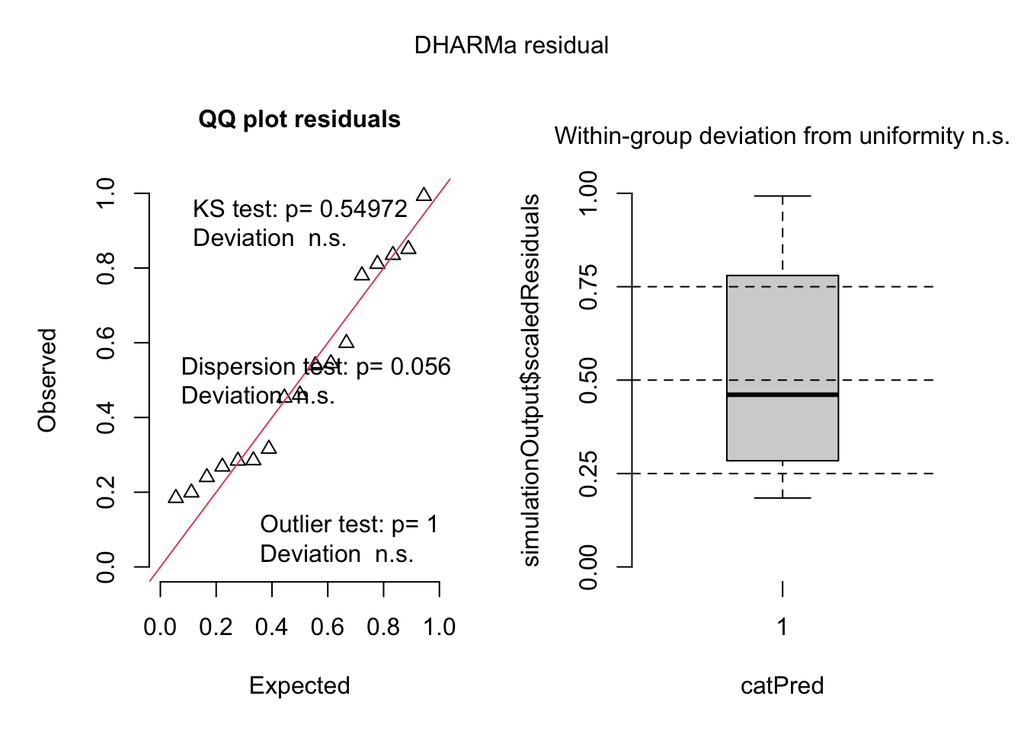

```
## Object of Class DHARMa with simulated residuals based on 250 simulations with refit = FALSE . See ?DHARMa::simulateResiduals for help.
##
## Scaled residual values: 0.9927232 0.4529156 0.8108822 0.5449791 0.8348305 0.8507394 0.2851888 0.1990384 0.4608805 0.3159422 0.5992869 0.1842957 0.2683226 0.2401475 0.2841838 0.780075 0.5398308
```

```r
simulateResiduals(mod_SR_0, plot=T)
```

None of the effects measured in the study explains the sex ratio of F0 individuals from eggs injected with plasmid or not.

### Power analysis

```
## [1] 0.47362
```

```
## [1] 9
```

```
## [1] 228
```

```
## [1] 0.5282073
```

```
## [1] 8
```

```
## [1] 149
```

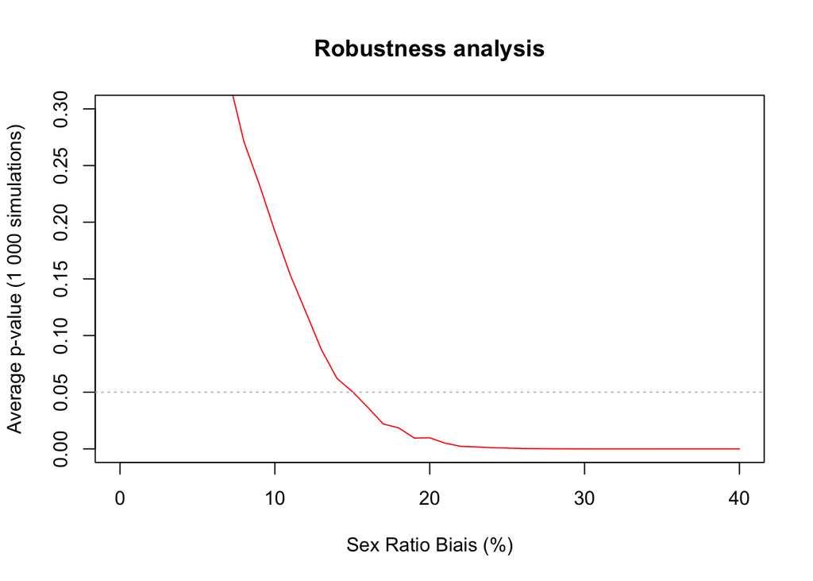

```
## integer(0)
```

# Impact of the cancer development on the offspring F1

```r
F1 <- read_delim("F1.txt",
    delim = "\t", escape_double = FALSE,
    trim_ws = TRUE)

F1$Rep <- as.factor(F1$Rep)
F1$Breeding_date <- as.factor(F1$Breeding_date)
F1$GFP <- as.factor(F1$GFP)
F1$parent <- as.factor(F1$parent)
F1$SR <- F1$femelles/F1$Total

summary(F1)
```

```
##  Rep    Breeding_date  GFP         parent      Nb_tenta         Total
##  1:16   210408 :10    neg:20   1      : 2   Min.   : 1.00   Min.   : 11.00
##  3:19   220210 : 6    pos:15   2      : 2   1st Qu.: 2.00   1st Qu.: 27.00
##         220202 : 5             3      : 2   Median : 2.00   Median : 47.00
##         210527 : 3             4      : 2   Mean   : 3.35   Mean   : 44.54
##         220201 : 3             5      : 2   3rd Qu.: 4.25   3rd Qu.: 53.50
##         220221 : 3             6      : 2   Max.   :10.00   Max.   :104.00
##         (Other): 5             (Other):23   NA's   :15
##      males          femelles       Nb_eclo_3d          SR
##  Min.   : 5.00   Min.   : 5.00   Min.   : 67.0   Min.   :0.1429
##  1st Qu.:14.50   1st Qu.:13.00   1st Qu.:116.5   1st Qu.:0.4444
##  Median :21.00   Median :22.00   Median :138.0   Median :0.5000
##  Mean   :21.77   Mean   :22.77   Mean   :146.0   Mean   :0.5006
##  3rd Qu.:26.50   3rd Qu.:28.50   3rd Qu.:161.0   3rd Qu.:0.5447
##  Max.   :59.00   Max.   :64.00   Max.   :309.0   Max.   :0.7529
##
```

## Size of the pond 3 days post fecundation

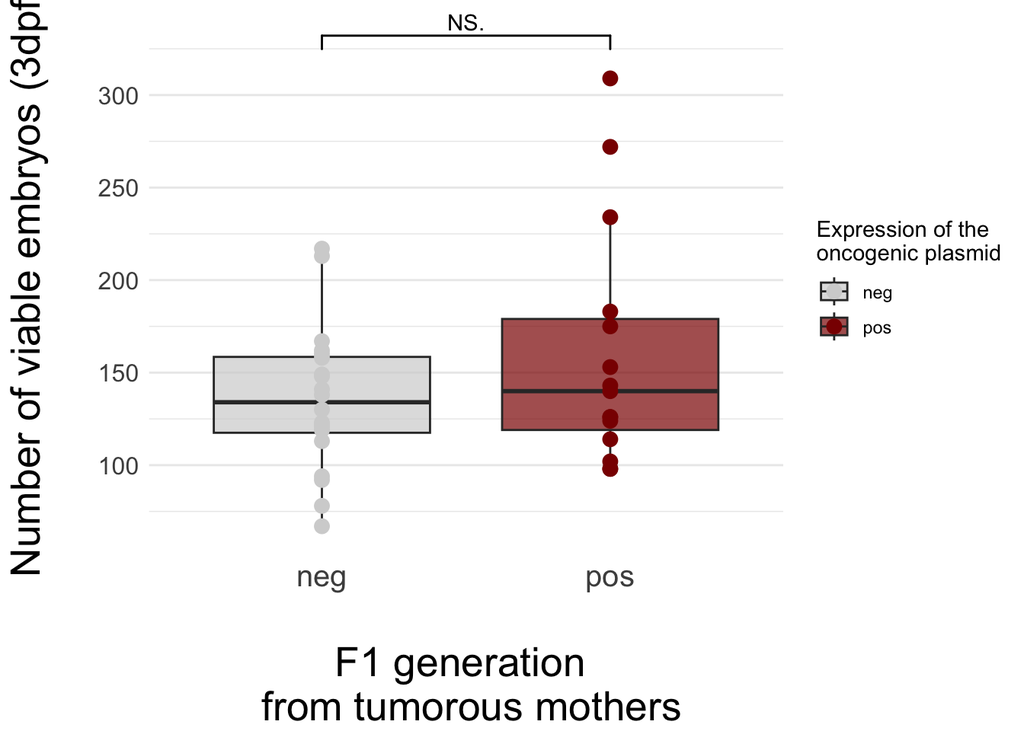

```r
(a <- ggplot(data = F1, aes(y= F1$Nb_eclo_3d, x=GFP, fill=GFP))+
  #geom_hline(yintercept=0.5, lty=2, color="darkgrey")+
  geom_boxplot(alpha=.7)+
  geom_point(aes(color=GFP), size = 3)+
  #ylim(0.1,0.9)+
  labs(color="Expression of the \noncogenic plasmid", fill="Expression of the \noncogenic plasmid")+
  ylab("Number of viable embryos (3dpf)\n")+
  xlab("\nF1 generation \n from tumorous mothers")+
  scale_fill_manual(values = c("lightgrey", "darkred"))+
  scale_color_manual(values = c("lightgrey", "darkred"))+
  theme_minimal()+
  theme(
    panel.grid.major.x = element_blank(),
        axis.title.x=element_text(vjust=0,
                                  size=20),  # X axis title
        axis.title.y=element_text(size=20, angle = 90),  # Y axis title
        axis.text.x=element_text(size=15,
                                 vjust=.5),  # X axis text
        axis.text.y=element_text(size=12))+
   ggsignif::geom_signif(comparisons = list(c("neg", "pos")), map_signif_level = TRUE, y_position = 320)
 )
```

```r
ggsave("SR_F1_Nb_egg.jpg", a, device = "jpg")
```

### Random effects selection

```
##            df     AICc
## mod_3dp_RN  4 647.6792
## mod_3dp_R1  3 645.1200
## mod_3dp_R0  2 786.1127
```

```
##  model weights
## [1] 0.218 0.782 0.000
```

Here it is important to take into account the influence of the breeding date on the total number of eggs released.

### Fixed effects selection

```
##              df     AICc
## mod_3dp_R1    3 653.5337
## mod_3dp_R1_0  2 698.0379
```

```
##  model weights
## [1] 1 0
```

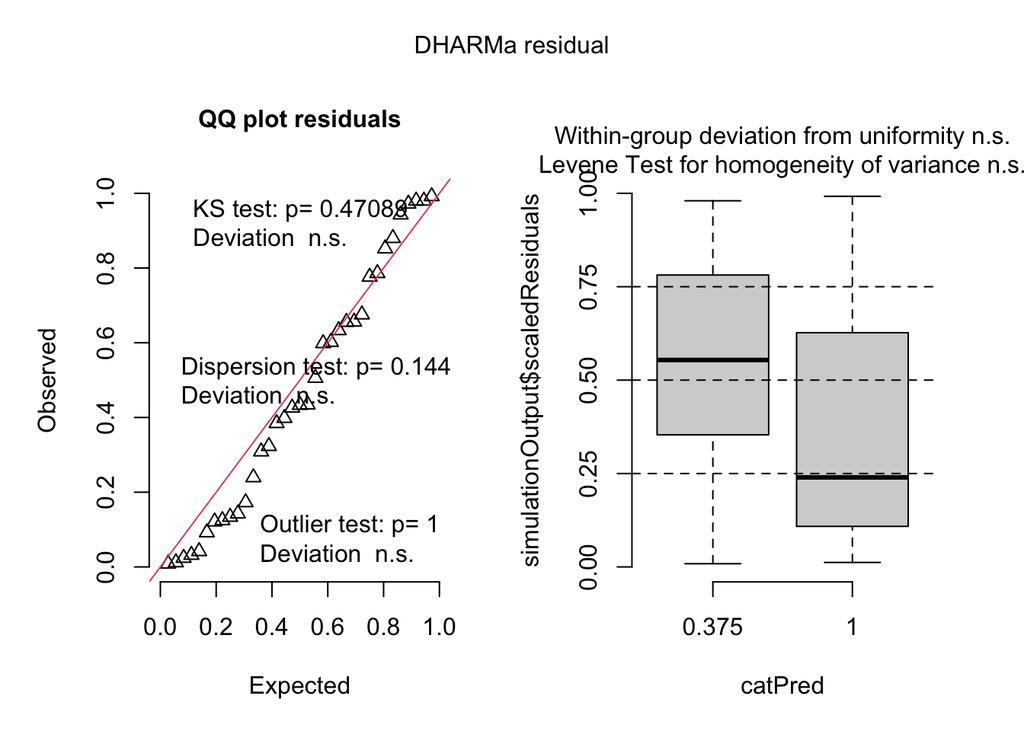

```
## Object of Class DHARMa with simulated residuals based on 250 simulations with refit = FALSE . See ?DHARMa::simulateResiduals for help.
##
## Scaled residual values: 0.3232768 0.1248757 0.98 0.024 0.6553846 0.1727659 0.3984593 0.5058337 0.008592583 0.6561907 0.4333007 0.852283 0.1212842 0.3088029 0.88 0.972 0.9430408 0.5985268 0.09226025 0.04191875 ...
```

|  | Nb_eclo_3d |  |  |
| --- | --- | --- | --- |
| Predictors | Incidence Rate Ratios | CI | p |
| GFP [pos] | 1.26 | 1.18 – 1.34 | **<0.001** |
| Random Effects |  |  |  |
| σ<sup>2</sup> | 0.01 |  |  |
| τ<sub>00</sub> <sub>Breeding_date</sub> | 0.05 |  |  |
| ICC | 0.88 |  |  |
| N <sub>Breeding_date</sub> | 11 |  |  |
| Observations | 35 |  |  |
| Marginal R<sup>2</sup> / Conditional R<sup>2</sup> | 0.186 / 0.905 |  |  |

The cancerous females lays more eggs than the non cancerous ones.

## Total number of individuals surviving 13 weeks

### Graphical representation

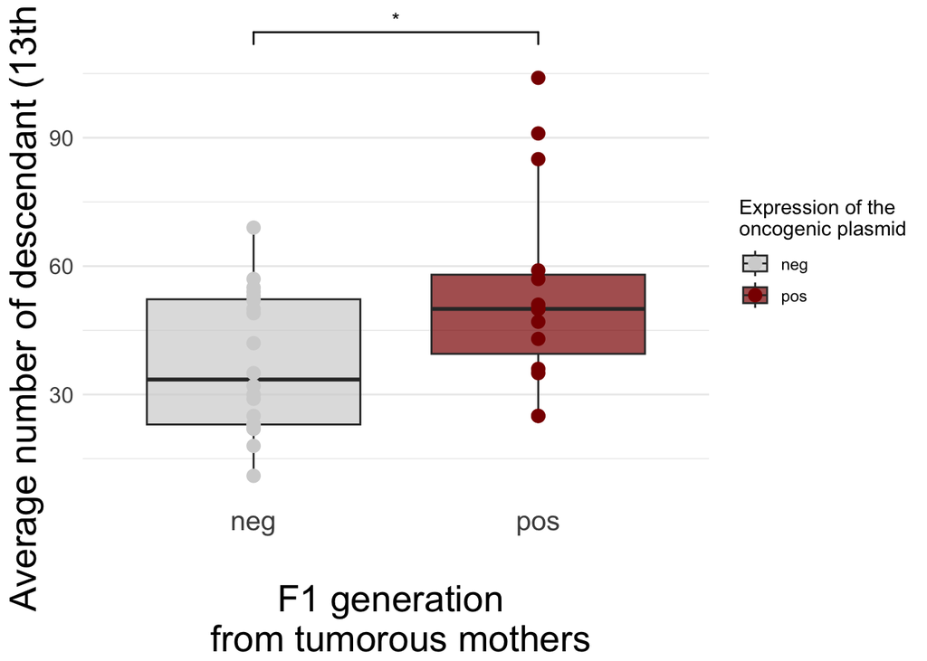

### Random effects selection

```
##            df     AICc
## mod_Mat_R1  4 332.1385
## mod_Mat_R2  3 329.5793
## mod_Mat_R0  2 335.7073
```

[output not shown]

### Fixed effects selection

```
##              df     AICc
## mod_Mat_R1    4 339.9583
## mod_Mat_R1_0  3 341.3565
```

```
##  model weights
## [1] 0.668 0.332
```

|  | cbind(Total, Nb_eclo_3d) |  |  |
| --- | --- | --- | --- |
| Predictors | Odds Ratios | CI | p |
| GFP [pos] | 1.19 | 1.05 – 1.35 | **0.005** |
| Random Effects |  |  |  |
| σ<sup>2</sup> | 3.29 |  |  |
| τ<sub>00</sub> <sub>Breeding_date:Rep</sub> | 0.01 |  |  |
| τ<sub>00</sub> <sub>Rep</sub> | 0.00 |  |  |
| N <sub>Breeding_date</sub> | 11 |  |  |
| N <sub>Rep</sub> | 2 |  |  |
| Observations | 35 |  |  |
| Marginal R<sup>2</sup> / Conditional R<sup>2</sup> | 0.002 / NA |  |  |

The cancerous females have an increased ratio of eggs layed reaching the adult age compared to the healthy ones.

## Sexe-ratio in the F1

Crosses were made every day. Each female was presented to a male several times until mating occurred. The eggs were then collected and the offspring sexed at 13 weeks.

### Random effects selection

```
##             df     AICc
## mod_SRF1_R1  6 221.6251
## mod_SRF1_R2  5 218.6941
## mod_SRF1_R0  4 221.9200
```

```
##  model weights
## [1] 0.161 0.699 0.139
```

### Fixed effects selection

```r
mod_SR_1 <- glmmTMB(data=F1, cbind(femelles, males)~GFP*Total*Nb_eclo_3d+ (1|Breeding_date), family = "binomial", REML = T)

mod_SR_2 <- glmmTMB(data=F1, cbind(femelles, males)~GFP+Total*Nb_eclo_3d+ (1|Breeding_date), family = "binomial", REML = T)
mod_SR_3 <- glmmTMB(data=F1, cbind(femelles, males)~GFP*Total+Nb_eclo_3d+ (1|Breeding_date), family = "binomial", REML = T)
mod_SR_4 <- glmmTMB(data=F1, cbind(femelles, males)~GFP*Nb_eclo_3d+Total+ (1|Breeding_date), family = "binomial", REML = T)

mod_SR_5 <- glmmTMB(data=F1, cbind(femelles, males)~Total*Nb_eclo_3d+ (1|Breeding_date), family = "binomial", REML = T)
mod_SR_6 <- glmmTMB(data=F1, cbind(femelles, males)~GFP*Total+ (1|Breeding_date), family = "binomial", REML = T)
mod_SR_7 <- glmmTMB(data=F1, cbind(femelles, males)~GFP*Nb_eclo_3d+ (1|Breeding_date), family = "binomial", REML = T)

mod_SR_8 <- glmmTMB(data=F1, cbind(femelles, males)~Total+Nb_eclo_3d+ (1|Breeding_date), family = "binomial", REML = T)
mod_SR_9 <- glmmTMB(data=F1, cbind(femelles, males)~GFP+Total+ (1|Breeding_date), family = "binomial", REML = T)
mod_SR_10 <- glmmTMB(data=F1, cbind(femelles, males)~GFP+Nb_eclo_3d+ (1|Breeding_date), family = "binomial", REML = T)
mod_SR_11 <- glmmTMB(data=F1, cbind(femelles, males)~GFP+Total+Nb_eclo_3d+ (1|Breeding_date), family = "binomial", REML = T)

mod_SR_12 <- glmmTMB(data=F1, cbind(femelles, males)~Nb_eclo_3d+ (1|Breeding_date), family = "binomial", REML = T)
mod_SR_13 <- glmmTMB(data=F1, cbind(femelles, males)~GFP+ (1|Breeding_date), family = "binomial", REML = T)
mod_SR_14 <- glmmTMB(data=F1, cbind(femelles, males)~Total+ (1|Breeding_date), family = "binomial", REML = T)
mod_SR_15 <- glmmTMB(data=F1, cbind(femelles, males)~1+ (1|Breeding_date), family = "binomial", REML = T)

AICc(mod_SR_1, mod_SR_2, mod_SR_3, mod_SR_4,
     mod_SR_5, mod_SR_6, mod_SR_7, mod_SR_8, mod_SR_9,
     mod_SR_10, mod_SR_11, mod_SR_12, mod_SR_13, mod_SR_14,
     mod_SR_15)
```

```
##           df     AICc
## mod_SR_1   9 306.6640
## mod_SR_2   6 265.8589
## mod_SR_3   6 255.8778
## mod_SR_4   6 257.5974
## mod_SR_5   5 260.9241
## mod_SR_6   5 241.6556
## mod_SR_7   5 245.5759
## mod_SR_8   4 240.4357
## mod_SR_9   4 231.0771
## mod_SR_10  4 233.0222
## mod_SR_11  5 245.1342
## mod_SR_12  3 228.7280
## mod_SR_13  3 219.3676
## mod_SR_14  3 226.5806
## mod_SR_15  2 215.6999
```

```r
Weights(AICc(mod_SR_1, mod_SR_2, mod_SR_3, mod_SR_4,
     mod_SR_5, mod_SR_6, mod_SR_7, mod_SR_8, mod_SR_9,
     mod_SR_10, mod_SR_11, mod_SR_12, mod_SR_13, mod_SR_14,
     mod_SR_15))
```

```
##  model weights
##  [1] 0.000 0.000 0.000 0.000 0.000 0.000 0.000 0.000 0.000 0.000 0.000 0.001
## [13] 0.137 0.004 0.857
```

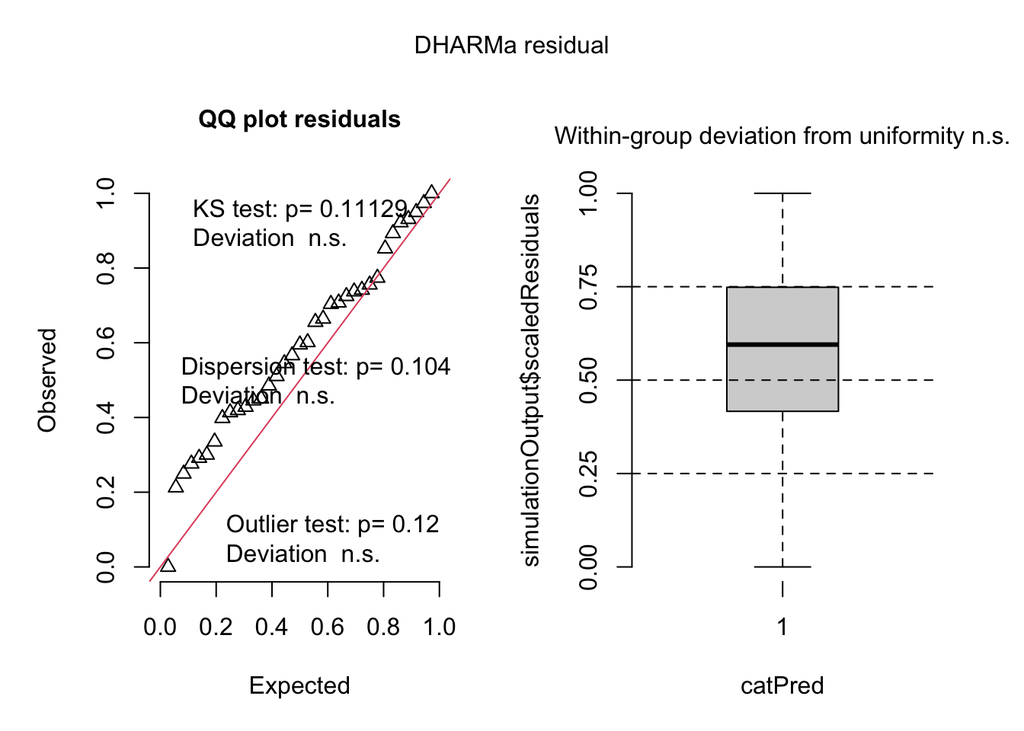

```
## Object of Class DHARMa with simulated residuals based on 250 simulations with refit = FALSE . See ?DHARMa::simulateResiduals for help.
##
## Scaled residual values: 0.9220831 1 0.9736931 0.4194178 0.2916285 0 0.7036044 0.4853739 0.9309452 0.2763059 0.3002132 0.4503181 0.7415309 0.2125713 0.6554951 0.2494273 0.3352893 0.445263 0.7246239 0.6013505 ...
```

```r
mod_SR_15 <- glmmTMB(data=F1, cbind(femelles, males)~1+ (1|Breeding_date), family = "binomial", REML = F)

simulateResiduals(mod_SR_15, plot = T)
```

There is absolutely no variations of the sex ratio than we can attributed to any effects we measured.

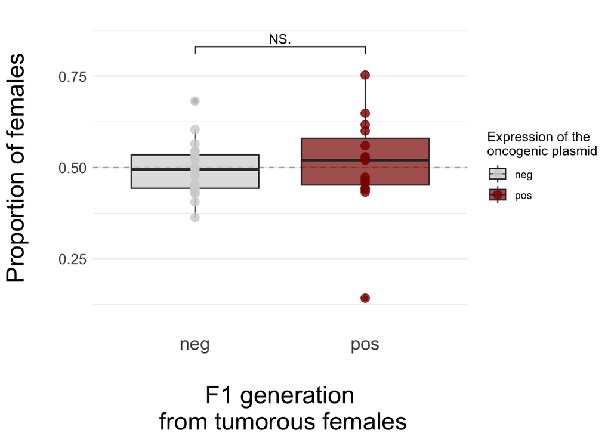

```r
(a <- ggplot(data = F1, aes(y= femelles/Total, x=GFP, fill=GFP))+
  geom_hline(yintercept=0.5, lty=2, color="darkgrey")+
  geom_boxplot(alpha=0.7)+
  geom_point(aes(color=GFP), size = 3, alpha = .8)+
  ylim(0.1,0.9)+
  labs(color="Expression of the \noncogenic plasmid", fill="Expression of the \noncogenic plasmid")+
  ylab("Proportion of females\n")+
  xlab("\nF1 generation\n from tumorous females")+
  scale_fill_manual(values = c("lightgrey", "darkred"))+
  scale_color_manual(values = c("lightgrey", "darkred"))+
  theme_minimal()+
  theme(
    panel.grid.major.x = element_blank(),
        axis.title.x=element_text(vjust=0,
                                  size=20),  # X axis title
        axis.title.y=element_text(size=20, angle = 90),  # Y axis title
        axis.text.x=element_text(size=15,
                                 vjust=.5),  # X axis text
        axis.text.y=element_text(size=12))+
   ggsignif::geom_signif(comparisons = list(c("neg", "pos")), map_signif_level = TRUE, y_position = 0.8)
 )
```

```r
ggsave("SR_F1T.jpg", a, device = "jpg")
```

### Power analysis

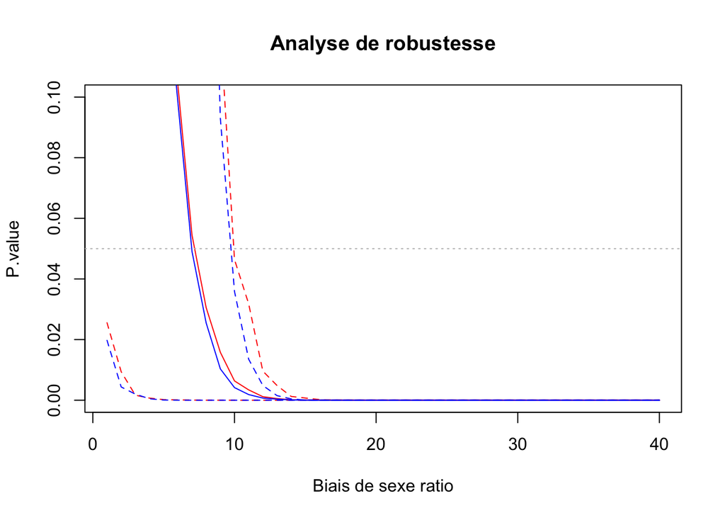

```
## integer(0)
```

```r
muSRCtrl <- mean(F1$SR[F1$GFP=="neg"])
muSRTum <- mean(F1$SR[F1$GFP=="pos"])

q1 <- NULL
q1.1 <- NULL
q3 <- NULL
q3.1 <- NULL
Biais <- NULL

Results <- matrix(0, 1000, 40)
Ratios_accept <- NULL

# Avec glm
i=1

for (j in 1 : 1000){
  for (i in 1:40){
  FemCtrl <- rbinom(n=20, size= 37, p= muSRCtrl)
  FemTum  <- rbinom(n=15, size= 53, p= (muSRCtrl+(i*0.01)))
  data <- data.frame(GFP=c(rep("Ctrl", 20), rep("Tum", 15)),
                     Total=c(rep(37, 20), rep(53, 15)),
                     Fem=c(FemCtrl, FemTum))
  Results[j, i] <- summary(glm(data = data, cbind(Fem, Total-Fem) ~ GFP, family = binomial))$coefficients[2,4]
  q1.1[i] <- quantile(Results[,i], 0.025)
  q3.1[i] <- quantile(Results[,i], 0.975)
  }
}

pm1 <- apply(Results, 2, mean)

# Avec un t - test

for (j in 1 : 1000){
  for (i in 1:40){
  FemCtrl <- rbinom(n=20, size= 37, p= muSRCtrl)
  FemTum  <- rbinom(n=15, size= 53, p= (muSRCtrl+(i*0.01)))
  data <- data.frame(GFP=c(rep("Ctrl", 20), rep("Tum", 15)),
                     Total=c(rep(37, 20), rep(53, 15)),
                     Fem=c(FemCtrl, FemTum))
  Results[j, i] <- t.test(FemCtrl/37, FemTum/53)$p.value
  q1[i] <- quantile(Results[,i], 0.025)
  q3[i] <- quantile(Results[,i], 0.975)
  }
}

pm <- apply(Results, 2, mean)
biais <- seq(1:40)

plot(biais, pm, type = "l", col = "red",
            main="Analyse de robustesse",
            xlab="Biais de sexe ratio",
            ylab = "P.value",
          ylim=c(0,0.10))+
    points(biais, q1, type = "l", lty=2, col="red")+
    points(biais, q3, type = "l", lty=2, col="red")+
  points(biais, pm1, type="l",col="blue")+
  points(biais, q1.1, type="l", lty=2, col="blue")+
  points(biais, q3.1, type="l",lty=2, col="blue")+
  abline(h=0.05, lty=3, col="grey")
```

### Citations

```r
citation("readr")
```

```
##
##   Wickham H, Hester J, Bryan J (2023). _readr: Read Rectangular Text
##   Data_. R package version 2.1.4,
##   <https://CRAN.R-project.org/package=readr>.
##
## A BibTeX entry for LaTeX users is
##
##   @Manual{,
##     title = {readr: Read Rectangular Text Data},
##     author = {Hadley Wickham and Jim Hester and Jennifer Bryan},
##     year = {2023},
##     note = {R package version 2.1.4},
##     url = {https://CRAN.R-project.org/package=readr},
##   }
```

```r
citation("GGally")
```

```
##
##   Schloerke B, Cook D, Larmarange J, Briatte F, Marbach M, Thoen E,
##   Elberg A, Crowley J (2021). _GGally: Extension to 'ggplot2'_. R
##   package version 2.1.2, <https://CRAN.R-project.org/package=GGally>.
##
## A BibTeX entry for LaTeX users is
##
##   @Manual{,
##     title = {GGally: Extension to 'ggplot2'},
##     author = {Barret Schloerke and Di Cook and Joseph Larmarange and Francois Briatte and Moritz Marbach and Edwin Thoen and Amos Elberg and Jason Crowley},
##     year = {2021},
##     note = {R package version 2.1.2},
##     url = {https://CRAN.R-project.org/package=GGally},
##   }
```

```r
citation("glmmTMB")
```

```
##
##   Mollie E. Brooks, Kasper Kristensen, Koen J. van Benthem, Arni
##   Magnusson, Casper W. Berg, Anders Nielsen, Hans J. Skaug, Martin
##   Maechler and Benjamin M. Bolker (2017). glmmTMB Balances Speed and
##   Flexibility Among Packages for Zero-inflated Generalized Linear Mixed
##   Modeling. The R Journal, 9(2), 378-400. doi: 10.32614/RJ-2017-066.
##
## A BibTeX entry for LaTeX users is
##
##   @Article{,
##     author = {Mollie E. Brooks and Kasper Kristensen and Koen J. {van Benthem} and Arni Magnusson and Casper W. Berg and Anders Nielsen and Hans J. Skaug and Martin Maechler and Benjamin M. Bolker},
##     title = {{glmmTMB} Balances Speed and Flexibility Among Packages for Zero-inflated Generalized Linear Mixed Modeling},
##     year = {2017},
##     journal = {The R Journal},
##     doi = {10.32614/RJ-2017-066},
##     pages = {378--400},
##     volume = {9},
##     number = {2},
##   }
```

```r
citation("sjPlot")
```

```
##
##   Lüdecke D (2023). _sjPlot: Data Visualization for Statistics in
##   Social Science_. R package version 2.8.15,
##   <https://CRAN.R-project.org/package=sjPlot>.
##
## A BibTeX entry for LaTeX users is
##
##   @Manual{,
##     title = {sjPlot: Data Visualization for Statistics in Social Science},
##     author = {Daniel Lüdecke},
##     year = {2023},
##     note = {R package version 2.8.15},
##     url = {https://CRAN.R-project.org/package=sjPlot},
##   }
```

```r
citation("DHARMa")
```

```
##
##   Hartig F (2022). _DHARMa: Residual Diagnostics for Hierarchical
##   (Multi-Level / Mixed) Regression Models_. R package version 0.4.6,
##   <https://CRAN.R-project.org/package=DHARMa>.
##
## A BibTeX entry for LaTeX users is
##
##   @Manual{,
##     title = {DHARMa: Residual Diagnostics for Hierarchical (Multi-Level / Mixed)
## Regression Models},
##     author = {Florian Hartig},
##     year = {2022},
##     note = {R package version 0.4.6},
##     url = {https://CRAN.R-project.org/package=DHARMa},
##   }
```

```r
citation("MuMIn")
```

```
##
##   Bartoń K (2023). _MuMIn: Multi-Model Inference_. R package version
##   1.47.5, <https://CRAN.R-project.org/package=MuMIn>.
##
## A BibTeX entry for LaTeX users is
##
##   @Manual{,
##     title = {MuMIn: Multi-Model Inference},
##     author = {Kamil Bartoń},
##     year = {2023},
##     note = {R package version 1.47.5},
##     url = {https://CRAN.R-project.org/package=MuMIn},
##   }
##
## ATTENTION: This citation information has been auto-generated from the
## package DESCRIPTION file and may need manual editing, see
## 'help("citation")'.
```

```r
citation("MASS")
```

```
##
##   Venables, W. N. & Ripley, B. D. (2002) Modern Applied Statistics with
##   S. Fourth Edition. Springer, New York. ISBN 0-387-95457-0
##
## A BibTeX entry for LaTeX users is
##
##   @Book{,
##     title = {Modern Applied Statistics with S},
##     author = {W. N. Venables and B. D. Ripley},
##     publisher = {Springer},
##     edition = {Fourth},
##     address = {New York},
##     year = {2002},
##     note = {ISBN 0-387-95457-0},
##     url = {https://www.stats.ox.ac.uk/pub/MASS4/},
##   }
```